# ESM 244: Assignment 1, Task 2

Author

Sophia Lecuona

# 1 Willamette Falls Fish Passage Time Series Summary (2001 - 2010)

### 1.0.1 Overview

[figure not shown]

Pacific Salmon and Steelhead. Credit: NOAA Fisheries.

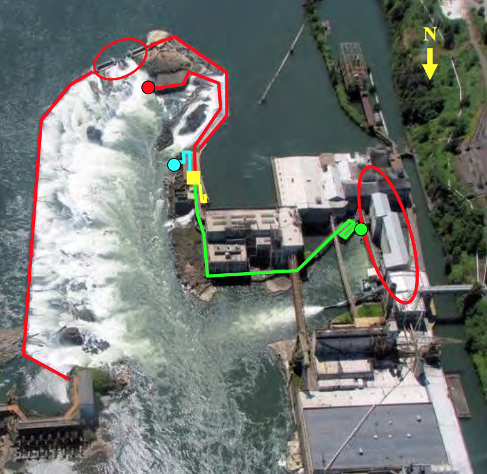

Willamette Falls Fish Ladder Project Area. The green line represents Leg 1, blue is Leg 2, red is Leg 3 of the Oregon Department of Fish and Wildlife Fish Ladder. Credit: Tim Shibahara – Fish Biologist; Portland General Electric.

Willamette Falls is a natural water fall in Oregon, USA. The Oregon Department of Fish and Wildlife worked to create fish ladders for a variety of fish species, as shown above. There are three “Legs”, or entrances, for the fish passage. There, counts of Chinook, Jack Chinook, Steelhead, Wild Steelhead, Sockeye, Coho Salmon, Jack Coho, Shad, Lamprey, Bull Trout, Chum Salmon, and Pink Salmon were taken daily at the Willamette Fish Passage project area.

Using data collected from the Columbia Basin Research organization, this report focuses on Coho, Jack Coho, and Steelhead during the period spanning from January 1st, 2001, to December 31st, 2010. In order to delve into the seasonality of these fish species, a comprehensive examination was undertaken, employing a time series approach, season plot visualization, and an annual count analysis.

Columbia Basin Research, Oregon Department of Fish & Wildlife, Washington Department of Fish & Wildlife, U.S. Army Corps of Engineers, NWD, Chelan, Douglas, and Grant County PUDs, Yakima Klickitat Fisheries Project, & Colville Tribes Fish & Wildlife (OBMEP),. (unpublished). DART Adult Passage Counts Graphics & Text: Data Available in DART for Willamette Falls / Sullivan Project, Willamette River [Dataset]. In *Columbia River DART (Data Access in Real Time)*. https://www.cbr.washington.edu/dart/query/adult_graph_text

The data for this analysis was shared by and accessed from [Columbia River DART](https://www.cbr.washington.edu/dart/query/adult_graph_text) (Data Access in Real Time), on January 27, 2023.

Metadata & info:[https://www.cbr.washington.edu/dart/wrappertype=html&fname=metainventory_WFF.html](https://www.cbr.washington.edu/dart/wrapper?type=html&fname=metainventory_WFF.html)

## 1.1 Part 1: An original time series of the Willamette Falls fish passage

```r
library(tidyverse)
library(here)
library(janitor)
library(ggplot2)
library(patchwork)
library(lubridate)
library(tsibble)
library(ggsci)
library(feasts)
library(fable)
library(wesanderson)
library(extrafont)
library(stringr)
```

### 1.1.1 Wrangle the data

```r
fish_passage <- read_csv(here('data/willamette_fish_passage.csv')) %>%
  clean_names()

clean_date <- fish_passage %>%
  mutate(date = lubridate::mdy(date)) %>%
  as_tsibble(key = NULL, ### if we had multiple sites, key by site
             index = date) %>%
  select(date, coho, jack_coho, steelhead) %>%
  pivot_longer(cols=c('coho', 'jack_coho', "steelhead"),
                    names_to='species',
                    values_to='count') %>%
  replace_na(list(count = 0)) %>%
  mutate(species = str_replace(species, pattern = '_', replacement = ' ')) %>%
  mutate(species = str_replace(species, 'coho', 'Coho')) %>%
  mutate(species = str_replace(str_to_title(species), 'jack_coho', 'Jack Coho')) %>%
  mutate(species = str_replace(species, 'steelhead', 'Steelhead'))
```

### 1.1.2 Visualize the time series

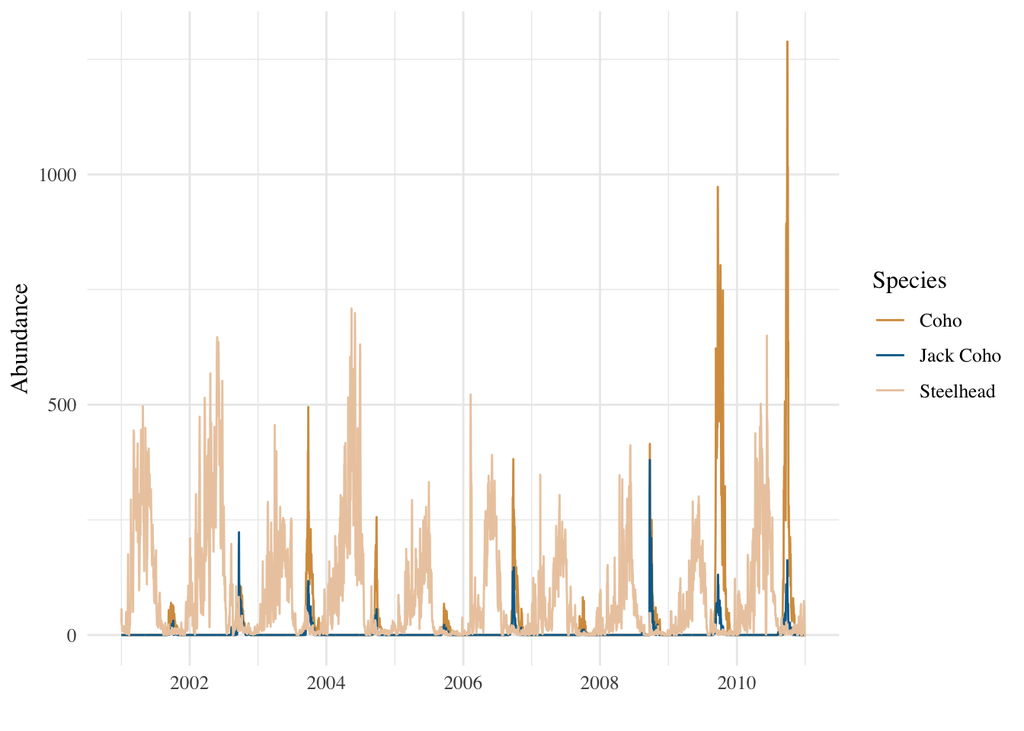

Figure 1: **Temporal Trend of Fish Abundance.** Daily abundance of Coho, Jack Coho, and Steelhead at the Willamette fish passage between January 01, 2001 to December 31st, 2010.

```r
# wanted to use the same palette as my seasonplot,
# however the colors looked too harsh when they are not continuous.
# So I looked for the closest colors I could find to make it cohesive.

ggplot(data = clean_date, aes(x = date, y = count, color = species)) +
  geom_line() +
  theme_minimal() +
  scale_color_manual(values = c("Coho" = wes_palette("Darjeeling2")[3],
                                "Jack Coho" = wes_palette("Darjeeling2")[2],
                                "Steelhead" = wes_palette("Darjeeling2")[1])) +
  labs(color = "Species",
       x = " ",
       y = "Abundance") +
  theme(text=element_text(size=12, family="serif"))
```

- Figure 1 depicts Coho Salmon with a possible increasing overall trend. Fall 2009 and Fall 2010 have substantial surges in abundance, reaching 1000 and 1250 counts, respectively.
- The abundance of Jack Coho has an overall neutral trend, with relatively smaller abundance than Coho and Steelhead. Abundance increases seasonally in the fall, in which Fall 2008 has the largest counts.
- There seems to be no overall trend for Steelhead, as the peaks tend to be between 300-500 counts. Each peak does seem seasonal, rising in late spring and early summer each year.